# Ch7P2 Visualization Types - Part II

Descriptive Analytics and Data Visualization

Yichen Qin (qinyn@ucmail.uc.edu), University of Cincinnati

2026-03-04

# Ch7P2 Visualization Types - II

In this chapter, we continue to discuss the commonly used visualization types. The following R packages are required to run the examples in this chapter.

```r
library(tidyverse)
library(ggforce)
library(readxl)
library(sunburstR)
library(RColorBrewer)
library(grid)
library(gridExtra)
library(graphics)
library(vcd)
library(ggrepel)
library(ggsci)
library(ggtern)
library(sqldf)
library(waterfalls)
library(treemapify)
```

# 1 Visualization of Association for Discrete Data

## 1.1 Mosaic Plot

A mosaic plot (also known as a Marimekko diagram) is a graphical method for visualizing data from two or more qualitative variables. It is the multidimensional extension of spineplots, which graphically display the same information for only one variable. It gives an overview of the data and makes it possible to recognize relationships between different variables.

To demonstrate the usage of the mosaic plot, we explore the Titanic data set from the ggplot2. This data set provides the information about the passengers who either survived or died on the Titanic’s maiden voyage. The information include economic status (ticket class), gender, age, and survival status. As we can see in the visualizaiton, people tended to protect women and children. Adult men sacrificed themselves to give children and women opportunities, and the crew sacrificed themselves to give higher-class people opportunities.

```r
library(tidyverse)
titanic=read_csv("data/titanic.csv")
titanic
```

```
## # A tibble: 2,201 × 4
##    Class Sex   Age   Survived
##    <chr> <chr> <chr> <chr>
##  1 3rd   Male  Child No
##  2 3rd   Male  Child No
##  3 3rd   Male  Child No
##  4 3rd   Male  Child No
##  5 3rd   Male  Child No
##  6 3rd   Male  Child No
##  7 3rd   Male  Child No
##  8 3rd   Male  Child No
##  9 3rd   Male  Child No
## 10 3rd   Male  Child No
## # ℹ 2,191 more rows
```

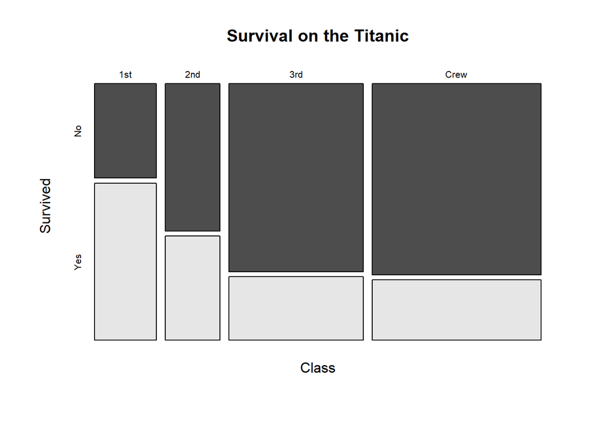

```r
mosaicplot(~ Class + Survived , data = titanic,
           main = "Survival on the Titanic", color = TRUE)
```

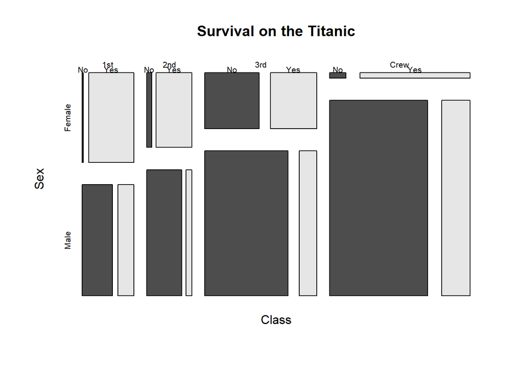

```r
mosaicplot(~ Class + Sex + Survived , data = titanic,
           main = "Survival on the Titanic", color = TRUE)
```

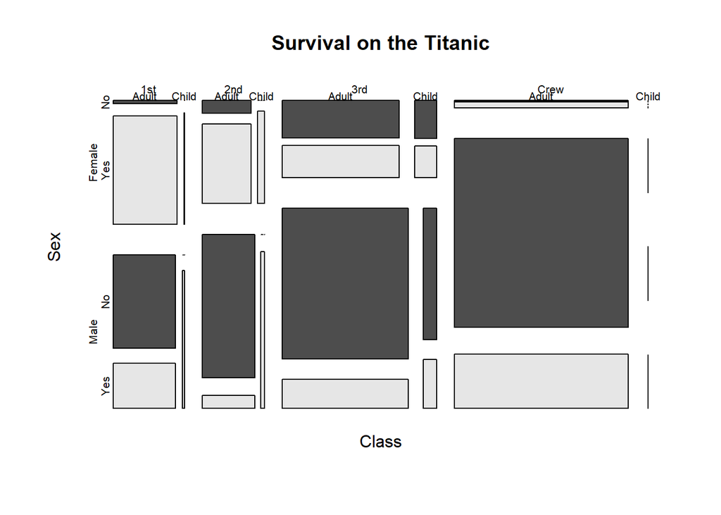

```r
mosaicplot(~ Class + Sex + Age + Survived, data = titanic,
           main = "Survival on the Titanic", color = TRUE)
```

```r
#mosaicplot(~ Sex + Age + Class + Survived, data = titanic, color = TRUE)
```

There are many choices in R to draw mosaic plots. We can use geom_rect() in ggplot2 or geom_mosaic() in ggmosaic or mosaicplot() in graphics or mosaic() in R package vcd. Additional examples of the mosaic plot are as follows.

```r
library(vcd)
mosaic(~ Sex + Class + Age + Survived, data = titanic,
  main = "Survival on the Titanic", shade = TRUE, legend = TRUE)
assoc(Titanic, shade=TRUE, legend=TRUE)
data001 <-read.csv("data/cinema.csv")
mosaicplot(~ year + release_date,  data =data001,
           shade = T, color = T, main ="cinema" ) +
  theme(axis.text.x=element_text(angle=-45, hjust= .1))
```

[output not shown]

## 1.2 Parallel Sets

A parallel sets plot is a new method for the visualization and interactive exploration of categorical data that shows data frequencies instead of the individual data points. The method is based on the axis layout of parallel coordinates, with boxes representing the categories and parallelograms between the axes showing the relations between categories.

We are using the Titanic data set from the ggplot2. This data set provides the information about the passengers on the Titanic’s maiden voyage, including their ticket class (economic status), gender, age, and survival status. Note that we have to reorganize the data set before using the parallel sets plot.

```r
library(ggforce) # Package
titanic=read_csv("data/titanic.csv")
titanic_freq = titanic %>%
  count(Class, Sex, Age, Survived, .drop = FALSE)
parallel_data14 <- gather_set_data(titanic_freq, c(1,4))
head(parallel_data14)
```

```
## # A tibble: 6 × 8
##   Class Sex    Age   Survived     n    id x     y
##   <chr> <chr>  <chr> <chr>    <int> <int> <chr> <chr>
## 1 1st   Female Adult No           4     1 Class 1st
## 2 1st   Female Adult Yes        140     2 Class 1st
## 3 1st   Female Child Yes          1     3 Class 1st
## 4 1st   Male   Adult No         118     4 Class 1st
## 5 1st   Male   Adult Yes         57     5 Class 1st
## 6 1st   Male   Child Yes          5     6 Class 1st
```

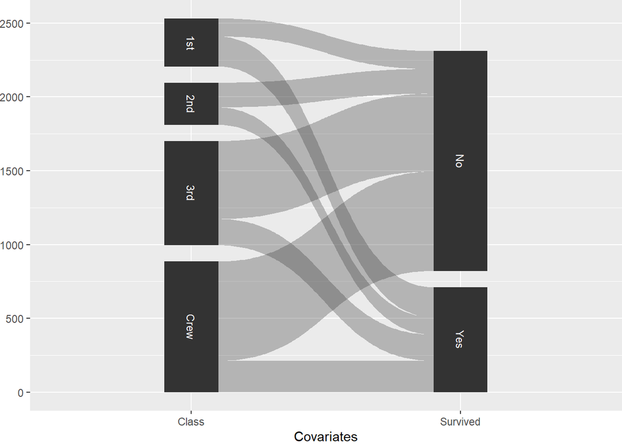

```r
ggplot(parallel_data14,
       aes(x = x,
           id = id,
           split = y,
           value = n
           )) +
  xlab("Covariates") +
  geom_parallel_sets(alpha = 0.3, axis.width = 0.2) +
  geom_parallel_sets_axes(axis.width = 0.2) +
  geom_parallel_sets_labels(color = 'white',size=3)
```

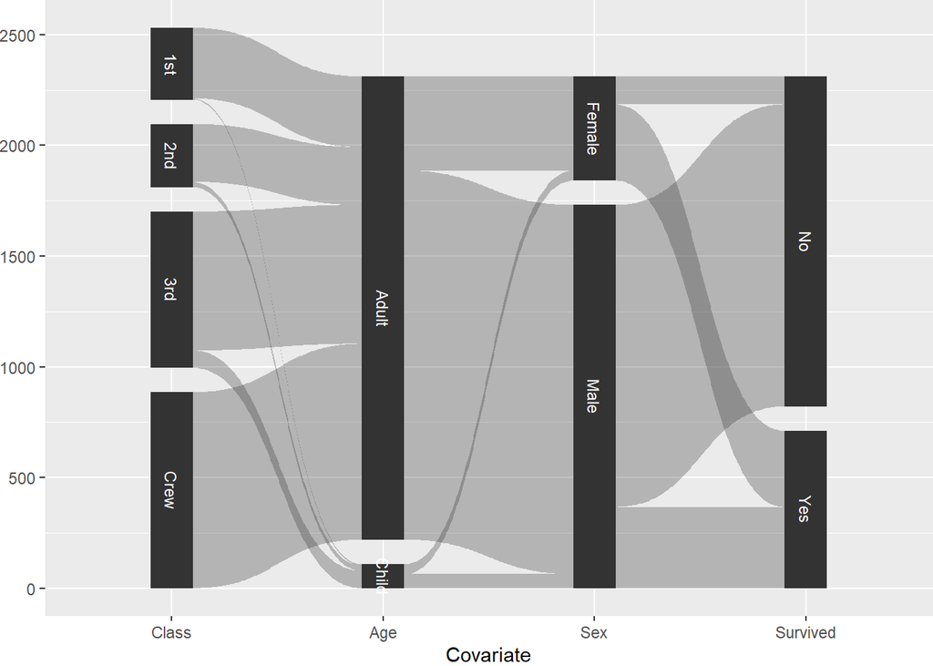

```r
parallel_data1234 <- gather_set_data(titanic_freq, 1:4)
ggplot(parallel_data1234, aes(x=factor(x, levels = c("Class", "Age","Sex","Survived")),
                              # we can control the order of the covariates in levels = xxx
                              id = id, split = y, value = n)) +
  geom_parallel_sets(alpha = 0.3, axis.width = 0.2) +
  geom_parallel_sets_axes(axis.width = 0.2) +
  geom_parallel_sets_labels(color = 'white',size=3) +
  xlab("Covariate")
```

If we would like to emphasize on the covariates’ association with survived.

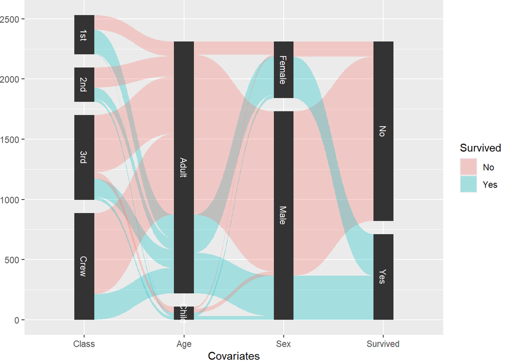

```r
ggplot(parallel_data1234, aes(x=factor(x, levels = c("Class", "Age", "Sex", "Survived")),
                              id = id, split = y, value = n)) +
  xlab("Covariates")+
  geom_parallel_sets(aes(fill = Survived), alpha = 0.3, axis.width = 0.2) +
  geom_parallel_sets_axes(axis.width = 0.2) +
  geom_parallel_sets_labels(color = 'white',size=3)
```

# 2 Visualization of Composition

## 2.1 Tree Map

Treemaps display hierarchical (tree-structured) data as a set of nested rectangles. Each branch of the tree is given a rectangle, which is then tiled with smaller rectangles representing subbranches. A leaf node’s rectangle has an area proportional to a specified dimension of the data.Often the leaf nodes are colored to show a separate dimension of the data.

We are analyzing the data set about Indonesia’s mobile phone market sales in the first half of 2020. The data is available at: https://www.kaggle.com/kurniakh/marketplace-data

```r
library(tidyverse)
library(treemapify)
phone<-read.csv("data/phone.csv")
head(phone)
```

```
##                      type      rmb sold brand    region    lnrmb
## 1            Apple iPhone  3459.90  597 Apple not-china 8.148995
## 2         Apple iPhone 11  6919.89 6205 Apple not-china 8.842155
## 3     Apple iPhone 11 Pro  8601.13 4473 Apple not-china 9.059649
## 4 Apple iPhone 11 Pro Max 10402.09 7087 Apple not-china 9.249762
## 5          Apple iPhone 4   787.20  130 Apple not-china 6.668482
## 6     Apple iPhone 4 CDMA   945.50    8 Apple not-china 6.851714
```

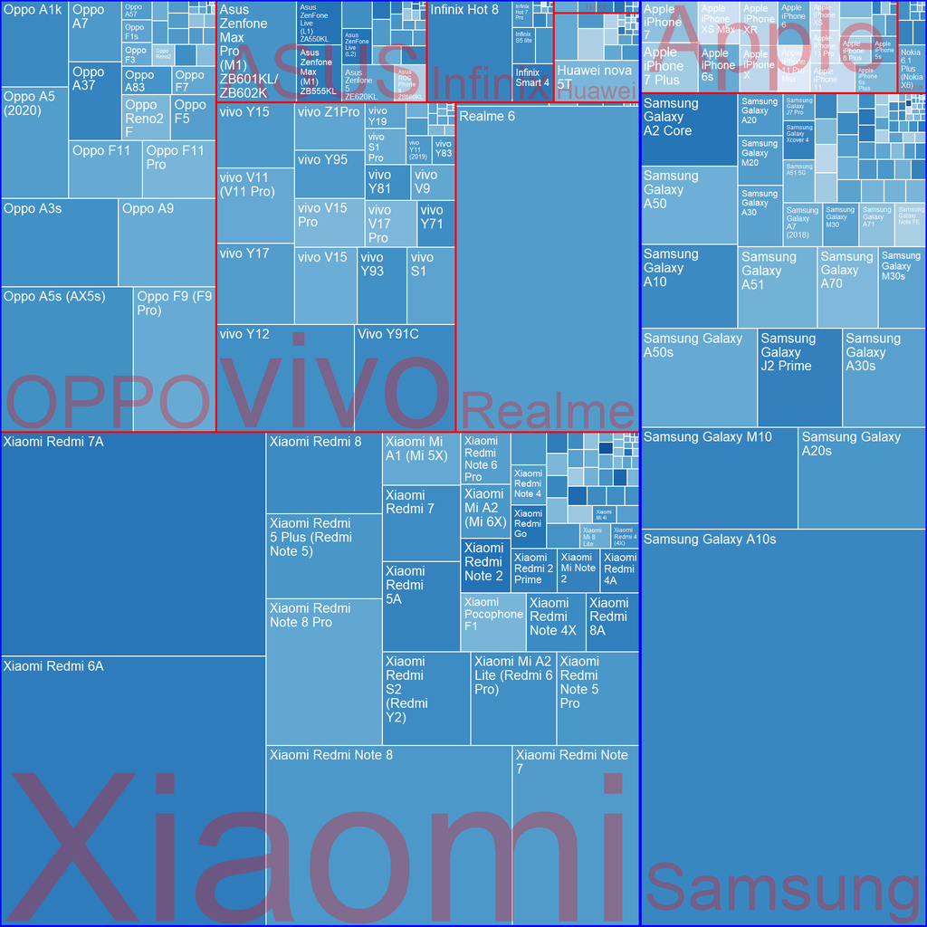

```r
ggplot(phone,
       aes(area = sold,
           subgroup = region,
           subgroup2 = brand,
           subgroup3 = type,
           fill=rmb))+
  geom_treemap()+
  geom_treemap_subgroup3_border(color="white",size=1)+
  geom_treemap_subgroup2_border(color="red",size=2)+
  geom_treemap_subgroup_border(color="blue",size=3)+
  #geom_treemap_subgroup_text(place = "centre", grow = TRUE, alpha = 0.5, colour ="white")+
  geom_treemap_subgroup2_text(place = "bottom", grow = TRUE, alpha = 0.3, colour ="red")+
  geom_treemap_text(aes(label=type),colour = "white", place = "topleft", reflow = TRUE, size=10)+
  scale_fill_distiller(palette="Blues",
                       name="phone\nprice\n(RMB)",
                       breaks = log(c(250, 500, 1000, 2000, 4000, 8000, 16000)),
                       labels = c(250, 500, 1000, 2000, 4000, 8000, 16000),
                       trans = "log10")
```

area=sold，the area is the sales volume of the mobile phone.

fill=rmb，the shade of the color represents the price (the price takes the logarithm ) of the phone. The cheaper price, the darker color.

subgroup2=brand, Chinese brands include Xiaomi, oppo, vivo, realme, etc., and non-Chinese brands include Apple, Samsung and Nokia.

subgroup3=type, based on the type of phone models, the most popular models in Indonesia are mainly cheaper models.

We can use tree map to visualize the titanic data set, however, it is less efficient than mosaic plot.

```r
titanic_df=as.data.frame(table(titanic[,c("Class","Sex","Survived")]))
ggplot(titanic_df,
       aes(area = Freq,
           subgroup = Class,
           subgroup2 = Sex,
           subgroup3 = Survived,
           label=paste("Class",Class,Sex,"Survived",Survived)))+
  geom_treemap()+
  geom_treemap_subgroup3_border(color="yellow",size=1)+
  geom_treemap_subgroup2_border(color="red",size=3)+
  geom_treemap_subgroup_border(color="blue",size=5)+
  geom_treemap_subgroup_text(place = "centre", grow = TRUE, alpha = 0.2, colour ="blue",fontface = "bold")+
  geom_treemap_subgroup2_text(place = "bottom", grow = FALSE, alpha = 0.2, colour ="red",fontface = "italic")+
  #geom_treemap_subgroup3_text(place = "top", grow = FALSE, alpha = 0.2, colour ="white",fontface = "italic")+
  geom_treemap_text(colour = "yellow", place = "topleft", reflow = FALSE,size=10)

# alternatively
titanic_df2=as.data.frame(table(titanic))
ggplot(titanic_df2,
       aes(area = Freq,
           subgroup = Class,
           subgroup2 = Sex,
           subgroup3 = Age,
           subgroup4 = Survived,
           label=paste("Class",Class,Sex,Age,"Survived",Survived)))+
  geom_treemap()+
  geom_treemap_subgroup3_border(color="yellow",size=1)+
  geom_treemap_subgroup2_border(color="red",size=3)+
  geom_treemap_subgroup_border(color="blue",size=5)+
  geom_treemap_subgroup_text(place = "centre", grow = TRUE, alpha = 0.2, colour ="blue",fontface = "bold")+
  geom_treemap_subgroup2_text(place = "bottom", grow = FALSE, alpha = 0.2, colour ="red",fontface = "italic")+
  geom_treemap_subgroup3_text(place = "left", grow = FALSE, alpha = 0.2, colour ="yellow",fontface = "italic",size=20)+
  geom_treemap_text(colour = "white", place = "topleft", reflow = FALSE,size=10)
```

[output not shown]

## 2.2 Sunburst Chart

A sunburst chart is typically used to visualize hierarchical data structures. A sunburst chart is also called wedge stack graph, radial hierarchy, circular bar plot, ring chart, multi-level pie chart, and radial treemap. The sunburst chart consists of an inner circle surrounded by rings of deeper hierarchy levels. The angle of each segment is either proportional to a value or divided equally under its parent node. All segments in sunburst charts may be colored according to which category or hierarchy level they belong to.

```r
library(tidyverse)
library(sunburstR)
library(RColorBrewer)
```

Data set: We visualize the data set on Indonesia’s mobile phone market sales in the first half of 2020 (https://www.kaggle.com/kurniakh/marketplace-data). Note this is a different data set from the previous treemap example.

```r
phone=read.csv("data/phone_sunburst.csv",header = TRUE)
phone_sun=phone[,c("PhoneModel","BrandCountry","Brand","Sold")]
phone_sun$Category=paste(phone$BrandCountry,phone$Brand,phone$PhoneModel,sep="-")
phone_sun=phone_sun[,c("Category","Sold")]
sund2b(phone_sun,
       color = colorRampPalette(brewer.pal(11,"Set3"))(35),              #add new colors
       showLabels = FALSE,
       rootLabel = "Total Phone Sold in Indonesia 2020")
```

[interactive chart not shown]

## 2.3 Ternary Plot

A ternary plot, ternary graph, triangle plot, simplex plot, Gibbs triangle or de Finetti diagram is a barycentric plot on three variables which sum to a constant. It graphically depicts the ratios of the three variables as positions in an equilateral triangle. It is used in physical chemistry, petrology, mineralogy, metallurgy, and other physical sciences to show the compositions of systems composed of three species. In population genetics, it is often called a de Finetti diagram. In game theory, it is often called a simplex plot. Ternary plots are tools for analyzing compositional data in the three-dimensional case.

```r
library(ggtern)
```

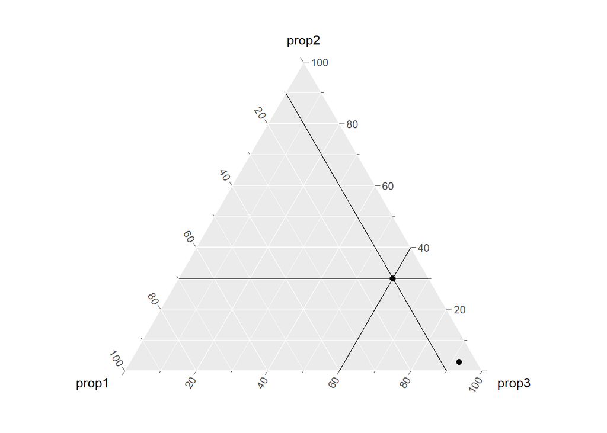

```r
df=data.frame(prop1=0.1,prop2=0.3,prop3=0.6)
df2=data.frame(prop1=0.05,prop2=0.03,prop3=0.92)
df=rbind(df,df2)
g1=ggtern(data=df,mapping=aes(x=prop1,y=prop2,z=prop3))+
  geom_point(size=2)+
  geom_Tline(Tintercept=c(0.3))+
  geom_Lline(Lintercept=c(0.1))+
  geom_Rline(Rintercept=c(0.6))
g1
```

USDA textural classification chart

We are using the “USDA” data set from package ggtern which is issued by the United States Department of Agriculture (USDA) in the form of a ternary diagram.

```
## Ignoring unknown labels:
## • colour : "Textural Class"
## • W : "Percent"
```

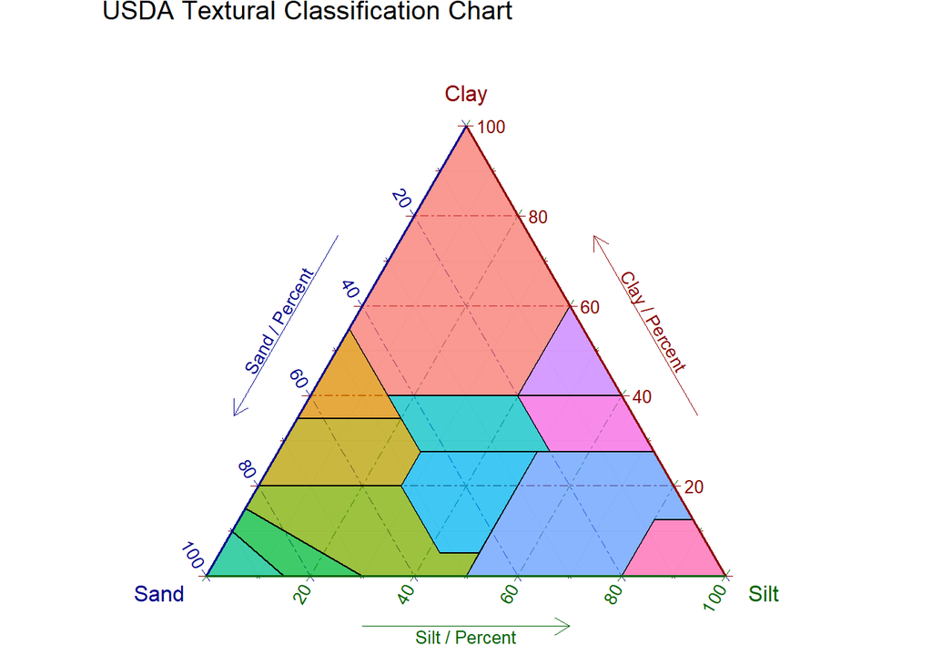

```r
data("USDA", package = "ggtern")
dfLabels <- plyr::ddply(USDA, "Label", function(df) {
   label <- as.character(df$Label[ 1 ])
  df$Angle <- switch(label, "Loamy Sand" = -35, 0)
  colMeans(df[setdiff(colnames(df), "Label")])
   })
f5a<-ggtern(data = USDA, mapping = aes(x = Sand, y = Clay, z = Silt))+ #three axes for Sand、Clay、Silt
  geom_polygon(mapping = aes(fill = Label),
                 alpha = 0.75, size = 0.5, color = "black")+ #add polygons，set the fill color based on Label，transparency as 0.75，size as 0.5，the color of the edge is black
  geom_text(data = dfLabels, mapping = aes(label = Label, angle = Angle),
              size = 2.5) +#add text which contains dfLabels's Label，Angle as tne angle
     theme_rgbw() + #R default background
     theme_showsecondary() +#R default background with Scale
     theme_showarrows() +
     custom_percent("Percent") +#add'percent'
     guides(color = "none", fill = "none")+
  labs(title = "USDA Textural Classification Chart",#title it。。。
          fill = "Textural Class", #the name of color for filling
       color = "Textural Class")# the name of color for edges
print(f5a)
```

## 2.4 Pie Chart/Donut Chart

```r
library(tidyverse)
college = read_csv("data/college.csv")
```

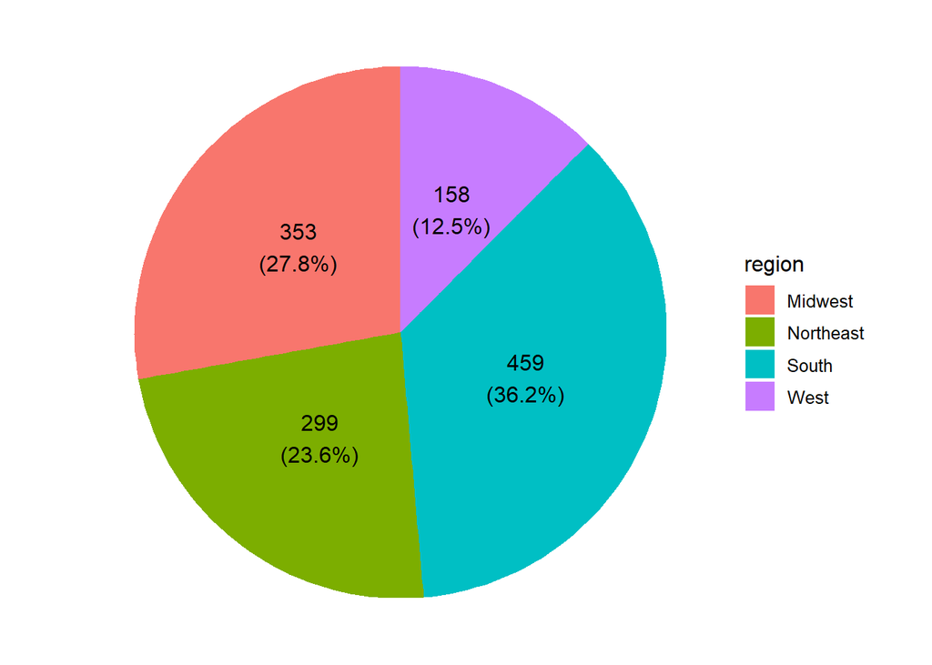

```r
college %>%
  group_by(region) %>%
  summarize(count = n()) %>%
  arrange(count) %>%
  ggplot(aes(x = 1,
             y = count,
             fill = region)) +
  geom_bar(stat = "identity",
           width = 1) +
  geom_text(aes(label = paste0(count, "\n(",
                               round(count / sum(count) * 100, 1),
                               "%)")),
            position = position_stack(vjust = 0.5)) +
  coord_polar(theta = "y") +
  theme_void()
```

**Single Donut Chart**

We use geom_rect() function from ggplot2 package to draw the plot as rectangle then the coord_polar(theta=“y”) can transfer the plot to circle. And we can control the size of the circle by adjusting the x-axis.

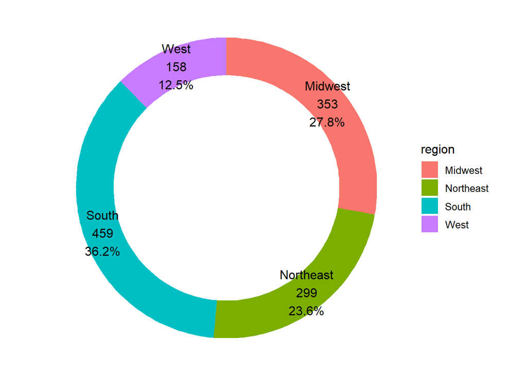

```r
college %>%
  group_by(region) %>%
  summarize(count = n(),
            fraction = n()/nrow(college) ) %>%
  mutate(max = cumsum(fraction),
         min = cumsum(fraction) - fraction,
         label_position = (max + min)/2,
         label = paste0(region, "\n", count, "\n", round(fraction*100,1), "%")) %>%
  ggplot(aes(ymax = max,
             ymin = min,
             xmax = 4,
             xmin = 3,
             fill = region)) +
  geom_rect() +
  geom_text(aes(y = label_position,
                label = label),
            x = 3.5) +
  coord_polar(theta = "y") +
  xlim(c(0, 4)) +
  theme_void()
```

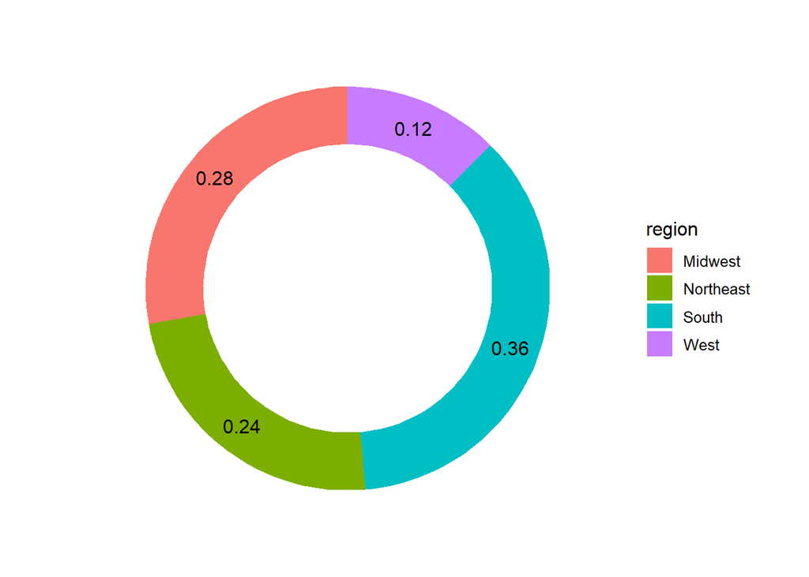

```r
college %>%
  group_by(region) %>%
  summarize(count = n(),
            fraction = n()/nrow(college) ) %>%
  arrange(fraction) %>%
  ggplot(aes(y = fraction,
             x = 3,
             fill = region)) +
  geom_bar(stat = "identity",
           width = 1) +
  geom_text(aes(label = round(fraction,2)),
            position = position_stack(vjust = 0.5)) +
  coord_polar(theta = "y") +
  xlim(c(0, 4)) +
  theme_void()
```

Nested donut chart

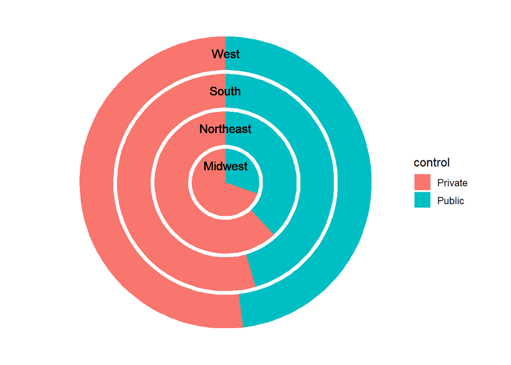

```r
college %>%
  ggplot() +
  geom_bar(aes(x = region,
               fill = control),
           position = "fill") +
  geom_text(aes(x = region,
                label = region),
            y = 0) +
  coord_polar(theta = "y") +
  theme_void()
```

# 3 Visualization of Change

## 3.1 Slope Graph

A slope graph is a lot like a line graph, but it plots only the change between two time points, without any regard for the points in between. It is based on the idea that humans are good at interpreting changes in directions, i.e., slopes.

Package

```r
library(tidyverse)
library(ggrepel)
library(RColorBrewer)
```

We are using the data set from the Fortune magazine, which describes the change of Revenue of top 10 Fortune 500 companies in 2018 and 2019.

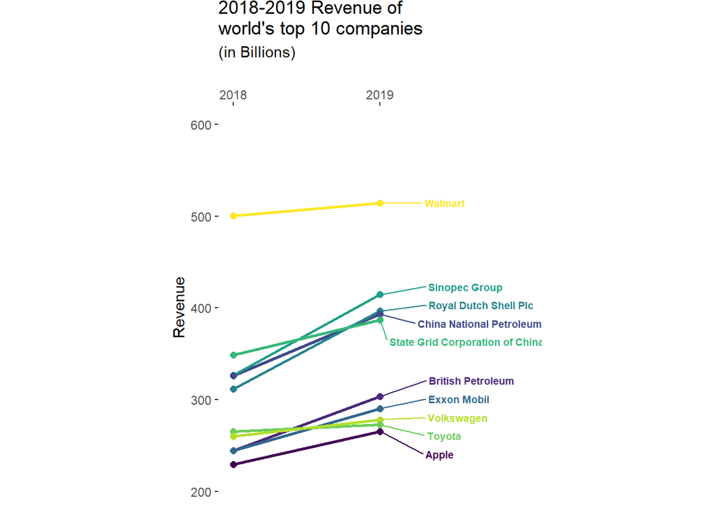

```r
df <- read.csv("data/top10.csv",header = T)
df %>%
  mutate(Name = factor(Name),
         Revenue = Revenue/1000) %>%
  ggplot(aes(x = Year,
             y=Revenue,
             group=Name,
             color=Name)) +
  geom_line(size=1) +
  geom_point(size=2) +
  labs(title= "2018-2019 Revenue of\nworld's top 10 companies",
       subtitle="(in Billions)") +
  scale_x_continuous(name = "",
                     position = "top",
                     breaks = c(2018, 2019),
                     labels = c("2018", "2019"),
                     limits = c(2018, 2020)) +
  scale_y_continuous(breaks = seq(200, 600, 100),
                     labels = format(seq(200, 600, 100), scientific = FALSE),
                     limits = c(200, 600)) +
  theme(legend.position = "none",
        aspect.ratio = 1.25,
        panel.background = element_rect(fill = "white")) +
  geom_text_repel(data = df %>% mutate(Revenue = Revenue/1000) %>% filter(Year == "2019"),
                  aes(label = Name) ,
                  hjust = "left",
                  fontface = "bold",
                  size = 2.5,
                  nudge_x = 0.3,
                  direction = "y") +
   scale_color_viridis_d()
```

## 3.2 Arrow Plot

[New York Times’ “Where the 1 Percent Have Gained the Most”](https://www.nytimes.com/2017/11/17/upshot/income-inequality-united-states.html)

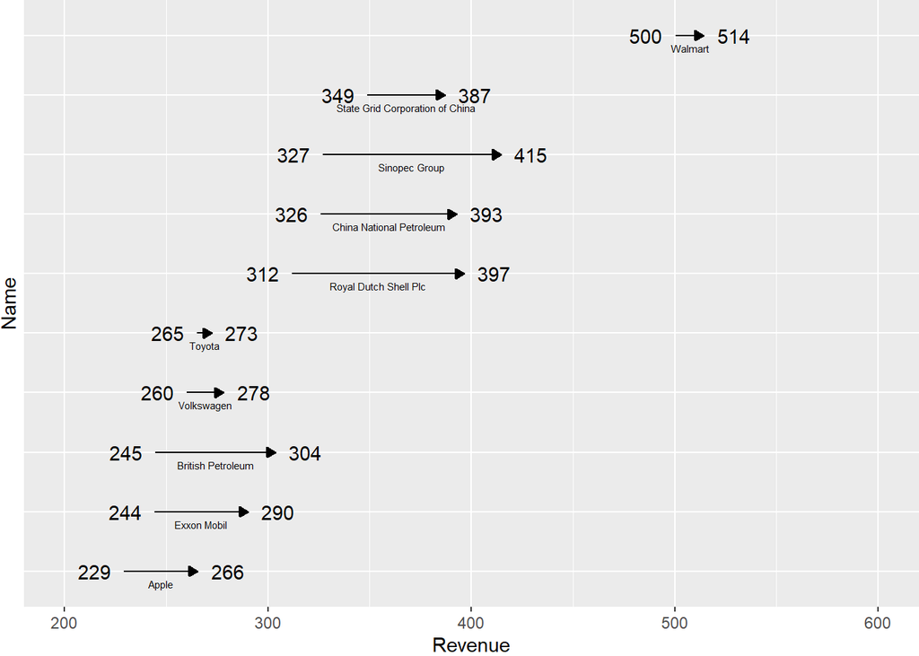

```r
df %>%
  mutate(Name = factor(Name),
         Revenue = Revenue/1000) %>%
  mutate(Name = fct_reorder(Name, Revenue, min)) %>%
  arrange(Year) %>%
  ggplot() +
  geom_path(aes(x = Revenue, y = Name),
            arrow = arrow(length=unit(0.2,"cm"), type = "closed")) +
  geom_text(aes(x = Revenue, y = Name, label = round(Revenue),
                hjust = ifelse(Year == 2018, 1.4, -0.4))) +
  geom_text(data = df %>%
              mutate(Revenue = Revenue/1000) %>%
              group_by(Name) %>%
              summarize(ave_Revenue = mean(Revenue)),
            aes(x = ave_Revenue, y = Name, label = Name),
            vjust = 2,
            size = 2) +
  coord_cartesian(xlim = c(200, 600)) +
  scale_x_continuous(breaks = seq(200, 600, 100),
                     labels = format(seq(200, 600, 100), scientific = FALSE)) +
  theme(axis.text.y = element_blank(),
        axis.ticks.y = element_blank())
```

## 3.3 Nightingale Rose Chart

```r
library(tidyverse)
Nightingale = read_csv("data/Nightingale.csv")
head(Nightingale)
```

```
## # A tibble: 6 × 10
##   Date       Month  Year  Army Disease Wounds Other Disease.rate Wounds.rate
##   <date>     <chr> <dbl> <dbl>   <dbl>  <dbl> <dbl>        <dbl>       <dbl>
## 1 1854-04-01 Apr    1854  8571       1      0     5          1.4         0
## 2 1854-05-01 May    1854 23333      12      0     9          6.2         0
## 3 1854-06-01 Jun    1854 28333      11      0     6          4.7         0
## 4 1854-07-01 Jul    1854 28722     359      0    23        150           0
## 5 1854-08-01 Aug    1854 30246     828      1    30        328.          0.4
## 6 1854-09-01 Sep    1854 30290     788     81    70        312.         32.1
## # ℹ 1 more variable: Other.rate <dbl>
```

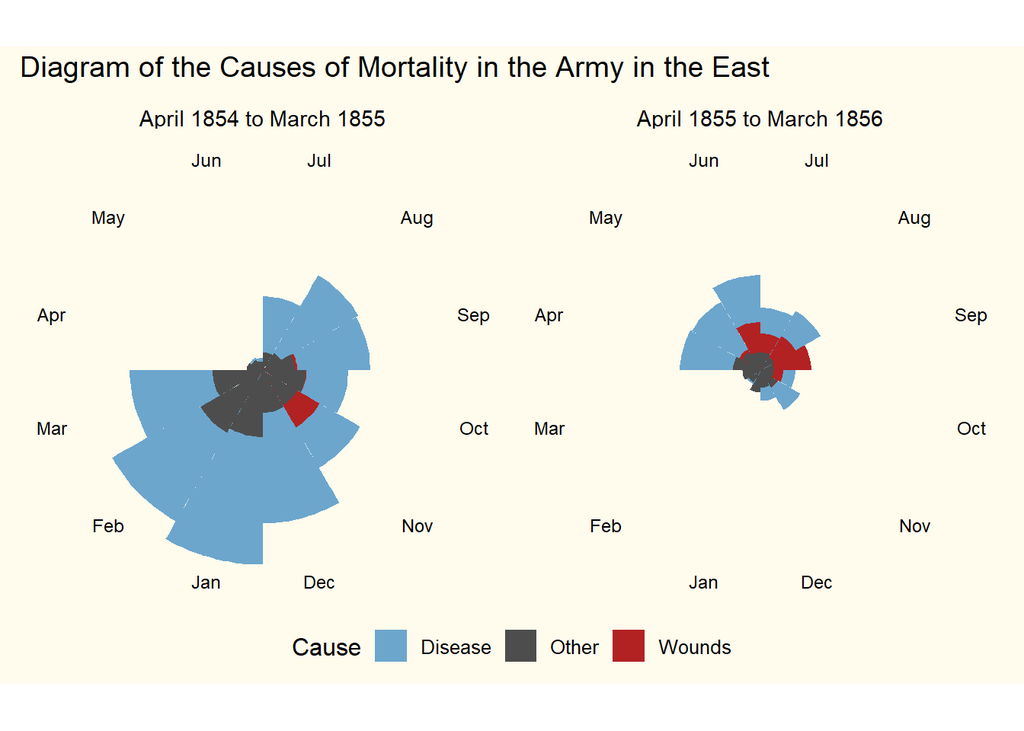

```r
Nightingale %>%
  select(Date, Month, Year, contains("rate")) %>%
  pivot_longer(cols = 4:6, names_to = "Cause", values_to = "Rate") %>%
  mutate(Cause = gsub(".rate", "", Cause),
         period = ifelse(Date <= as.Date("1855-03-01"),
                         "April 1854 to March 1855",
                         "April 1855 to March 1856"),
         Month = fct_relevel(Month,
                             "Jul", "Aug", "Sep", "Oct", "Nov", "Dec",
                             "Jan", "Feb", "Mar", "Apr", "May", "Jun")) %>%
  ggplot(aes(Month, Rate)) +
  geom_col(aes(fill = Cause), width = 1, position = "identity") +
  coord_polar() +
  facet_wrap(~period) +
  scale_fill_manual(values = c("skyblue3", "grey30", "firebrick")) +
  scale_y_sqrt() +
  theme_void() +
  theme(axis.text.x = element_text(size = 9),
        strip.text = element_text(size = 11),
        legend.position = "bottom",
        plot.background = element_rect(fill = alpha("cornsilk", 0.5)),
        plot.margin = unit(c(10, 10, 10, 10), "pt"),
        plot.title = element_text(vjust = 5)) +
  ggtitle("Diagram of the Causes of Mortality in the Army in the East")
```

# 4 Others

## 4.1 Cleveland Dot Plot/Lollipop Chart

A Cleveland dot plot proposed by William S. Cleveland and Robert McGill (https://www.jstor.org/stable/2288400) is a great alternative to a simple bar chart, particularly if you have more than a few items, in which case a bar chart can easily look cluttered. In the same amount of space, many more values can be included in the Cleveland dot plot, and it is easy to read as well. A Cleveland dot plot typically plots a categorical variable against a numeric variable.

Note that even though the bar plot can visualize whatever the Cleveland dot plot visualizes, the bar plot often costs more data-ink compared to the Cleveland dot plot. Often times, the Cleveland dot plot can be more efficient.

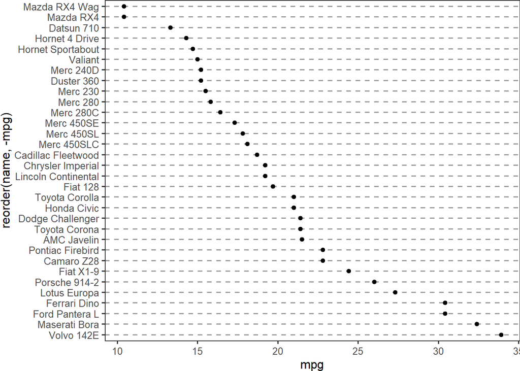

```r
mtcars_revised <- mtcars %>%
                  arrange(mpg) %>%
                  mutate(name = row.names(mtcars)) %>%
                  mutate(name = factor(name, levels = .$name))
ggplot(mtcars_revised, aes(x = mpg, y = reorder(name,-mpg), label = mpg) ) +
  geom_point() +
  theme_bw() +
  theme(
    panel.grid.major.x = element_blank(),
    panel.grid.minor.x = element_blank(),
    panel.grid.major.y = element_line(colour = "grey60", linetype = "dashed")
  )
```

A lollipop chart is a simple modification of the Cleveland dot plot. In addition to the dots, a lollipop chart contains lines that tie each categories to their relative dot, forming lollipops. A lollipop chart is great for comparing multiple categories as it aids the reader in aligning categories to points but minimizes the amount of ink on the graphic.

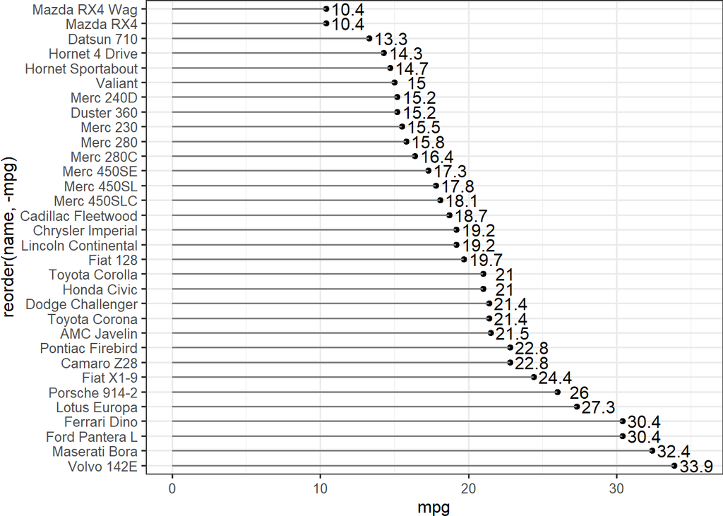

```r
ggplot(mtcars_revised, aes(x = mpg, y = reorder(name,-mpg), label = mpg) ) +
  geom_point() +
  geom_text(nudge_x = 1.5) +
  geom_segment(aes(x = 0, xend = mpg,
                   y = name, yend = name), color = "grey50") +
  theme_bw()
```

There are many extensions of the Cleveland dot plot and the lollipop chart.

```r
mpg_revised <- mpg %>% mutate(brandmodel=paste(manufacturer, model)) %>%
                  group_by(brandmodel) %>%
                  summarize(avg_hwy=mean(hwy, na.rm=TRUE),
                            avg_cty=mean(cty, na.rm=TRUE))
ggplot(mpg_revised) +
  geom_point(aes(avg_hwy, brandmodel),col="blue") +
  geom_point(aes(avg_cty, brandmodel),col="red") +
  geom_segment(aes(x = avg_cty, xend = avg_hwy,
                   y = brandmodel, yend = brandmodel), color = "grey50")+
  geom_text(aes(x = avg_cty, y=brandmodel, label = round(avg_cty, 1)), size = 3, hjust = 1.5) +
  geom_text(aes(x = avg_hwy, y=brandmodel, label = round(avg_hwy, 1)), size = 3, hjust = -.5)
```

[output not shown]

## 4.2 Waterfall Plot

The waterfalls package is based on ggplot2. We are going to use the function waterfall in the package to draw the plot.

Data resource: MIGA Summary Income Statement From World Bank Financial Open Data

```r
library(waterfalls)
```

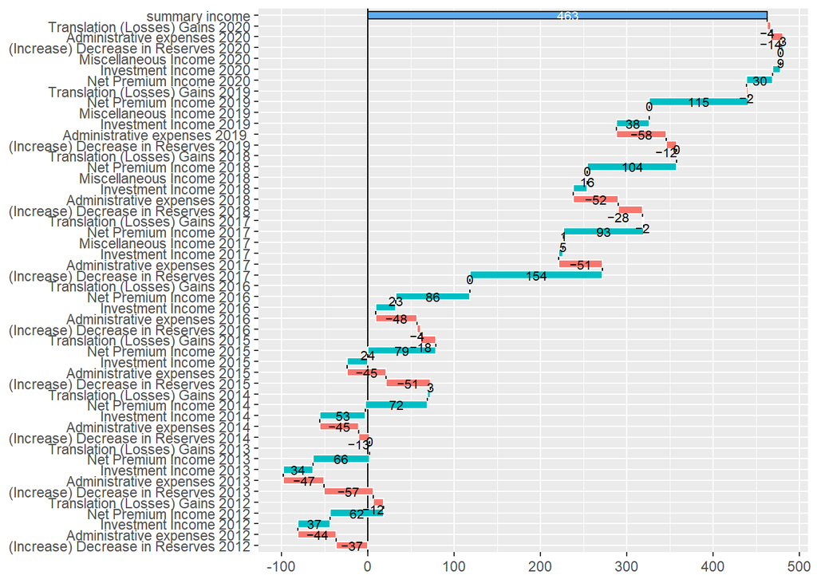

```r
miga<-read.csv("data/miga.csv")
miga$Item<-as.character(miga$Item)
waterfall(.data=miga,values =miga$Amount,labels =miga$Item,
          calc_total = TRUE,
          total_rect_color = "steelblue2",
          total_axis_text = "summary income",
          rect_border = "white",
          fill_by_sign =TRUE)+
  coord_flip()
```

Income:Investment Income;Net Premium Income Expenses:Decrease in Reserves;Administrative expenses